# EDA-Project

Shimaa Elabd

Dec 13 2018

# Introduction

Exploring this dataset about Red Wine Quality.

The variables included in the Red Wine dataset:

```
##  [1] "fixed.acidity"        "volatile.acidity"     "citric.acid"
##  [4] "residual.sugar"       "chlorides"            "free.sulfur.dioxide"
##  [7] "total.sulfur.dioxide" "density"              "pH"
## [10] "sulphates"            "alcohol"              "quality"
```

And the variables are of type:

```
## 'data.frame':    1599 obs. of  12 variables:
##  $ fixed.acidity       : num  7.4 7.8 7.8 11.2 7.4 7.4 7.9 7.3 7.8 7.5 ...
##  $ volatile.acidity    : num  0.7 0.88 0.76 0.28 0.7 0.66 0.6 0.65 0.58 0.5 ...
##  $ citric.acid         : num  0 0 0.04 0.56 0 0 0.06 0 0.02 0.36 ...
##  $ residual.sugar      : num  1.9 2.6 2.3 1.9 1.9 1.8 1.6 1.2 2 6.1 ...
##  $ chlorides           : num  0.076 0.098 0.092 0.075 0.076 0.075 0.069 0.065 0.073 0.071 ...
##  $ free.sulfur.dioxide : num  11 25 15 17 11 13 15 15 9 17 ...
##  $ total.sulfur.dioxide: num  34 67 54 60 34 40 59 21 18 102 ...
##  $ density             : num  0.998 0.997 0.997 0.998 0.998 ...
##  $ pH                  : num  3.51 3.2 3.26 3.16 3.51 3.51 3.3 3.39 3.36 3.35 ...
##  $ sulphates           : num  0.56 0.68 0.65 0.58 0.56 0.56 0.46 0.47 0.57 0.8 ...
##  $ alcohol             : num  9.4 9.8 9.8 9.8 9.4 9.4 9.4 10 9.5 10.5 ...
##  $ quality             : Ord.factor w/ 6 levels "3"<"4"<"5"<"6"<..: 3 3 3 4 3 3 3 5 5 3 ...
```

The summary statistics for residual sugar:

```
##    Min. 1st Qu.  Median    Mean 3rd Qu.    Max.
##   0.900   1.900   2.200   2.539   2.600  15.500
```

The summary statistics for chlorides:

```
##    Min. 1st Qu.  Median    Mean 3rd Qu.    Max.
## 0.01200 0.07000 0.07900 0.08747 0.09000 0.61100
```

# Univariate Plots Section

```
## Observations: 1,599
## Variables: 12
## $ fixed.acidity        <dbl> 7.4, 7.8, 7.8, 11.2, 7.4, 7.4, 7.9, 7.3, ...
## $ volatile.acidity     <dbl> 0.700, 0.880, 0.760, 0.280, 0.700, 0.660,...
## $ citric.acid          <dbl> 0.00, 0.00, 0.04, 0.56, 0.00, 0.00, 0.06,...
## $ residual.sugar       <dbl> 1.9, 2.6, 2.3, 1.9, 1.9, 1.8, 1.6, 1.2, 2...
## $ chlorides            <dbl> 0.076, 0.098, 0.092, 0.075, 0.076, 0.075,...
## $ free.sulfur.dioxide  <dbl> 11, 25, 15, 17, 11, 13, 15, 15, 9, 17, 15...
## $ total.sulfur.dioxide <dbl> 34, 67, 54, 60, 34, 40, 59, 21, 18, 102, ...
## $ density              <dbl> 0.9978, 0.9968, 0.9970, 0.9980, 0.9978, 0...
## $ pH                   <dbl> 3.51, 3.20, 3.26, 3.16, 3.51, 3.51, 3.30,...
## $ sulphates            <dbl> 0.56, 0.68, 0.65, 0.58, 0.56, 0.56, 0.46,...
## $ alcohol              <dbl> 9.4, 9.8, 9.8, 9.8, 9.4, 9.4, 9.4, 10.0, ...
## $ quality              <ord> 5, 5, 5, 6, 5, 5, 5, 7, 7, 5, 5, 5, 5, 5,...
```

## Quality

```
##   3   4   5   6   7   8
##  10  53 681 638 199  18
```

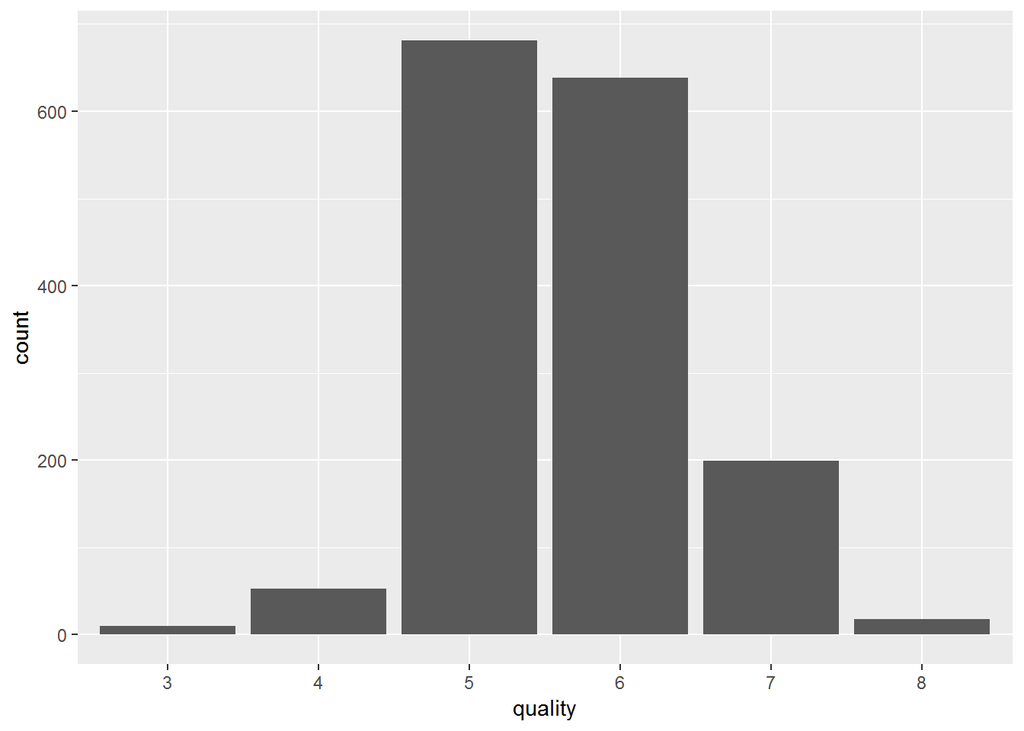

We can conclude that the quality variable is normally distributed. The most of red wines have a quality ranking of 5 and 6.

## Alcohol

```
##    Min. 1st Qu.  Median    Mean 3rd Qu.    Max.
##    8.40    9.50   10.20   10.42   11.10   14.90
```

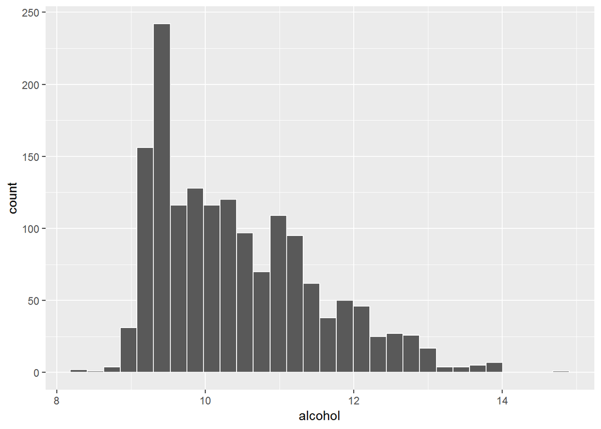

Alcohol is right skewed and have a Median = 10.20 and Mean = 10.42

## pH

```
##    Min. 1st Qu.  Median    Mean 3rd Qu.    Max.
##   2.740   3.210   3.310   3.311   3.400   4.010
```

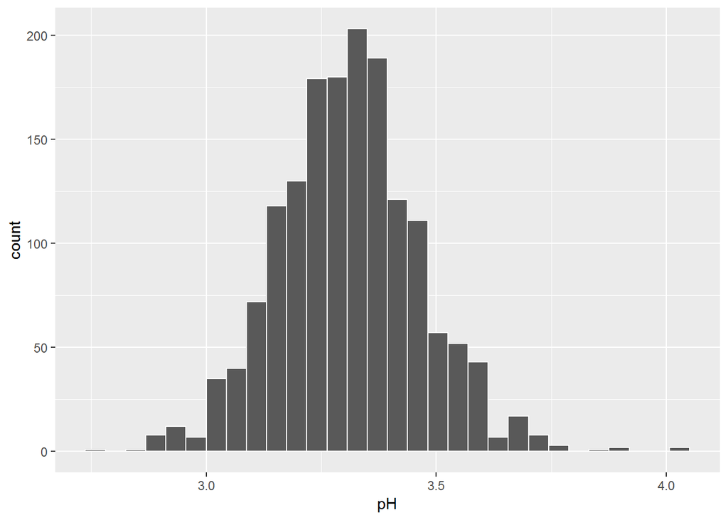

## Volatile acidity

```
##    Min. 1st Qu.  Median    Mean 3rd Qu.    Max.
##  0.1200  0.3900  0.5200  0.5278  0.6400  1.5800
```

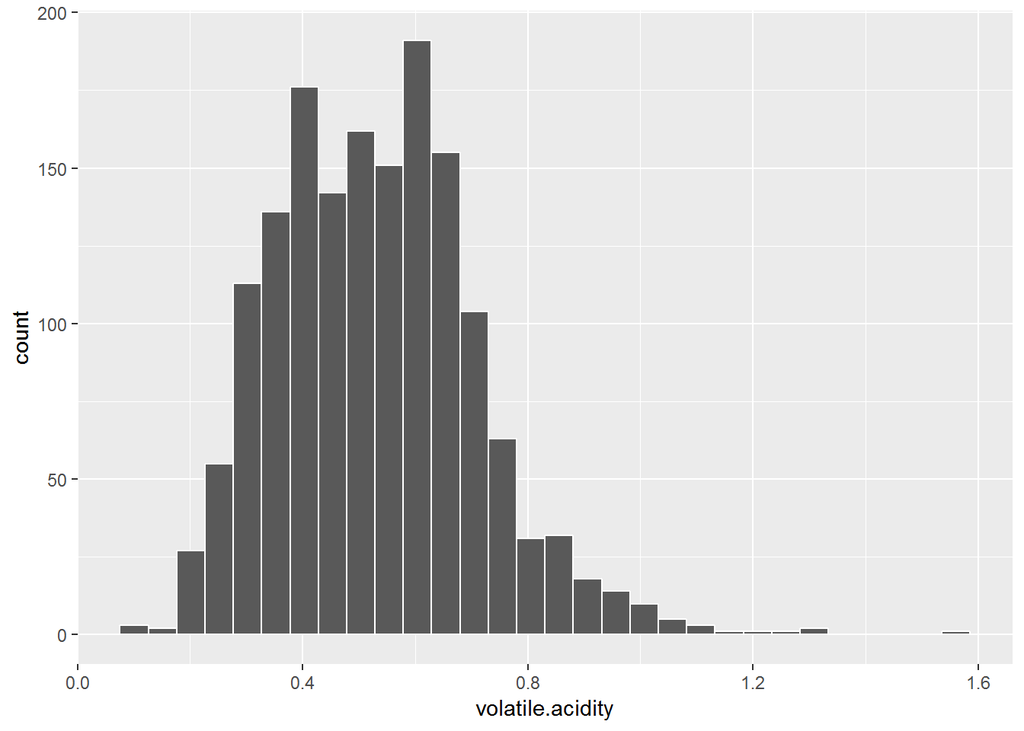

The distribution of volatile acidity is non-symmetric and bimodal with two peaks at 0.4 and 0.6.

## Citric acid

```
##    Min. 1st Qu.  Median    Mean 3rd Qu.    Max.
##   0.000   0.090   0.260   0.271   0.420   1.000
```

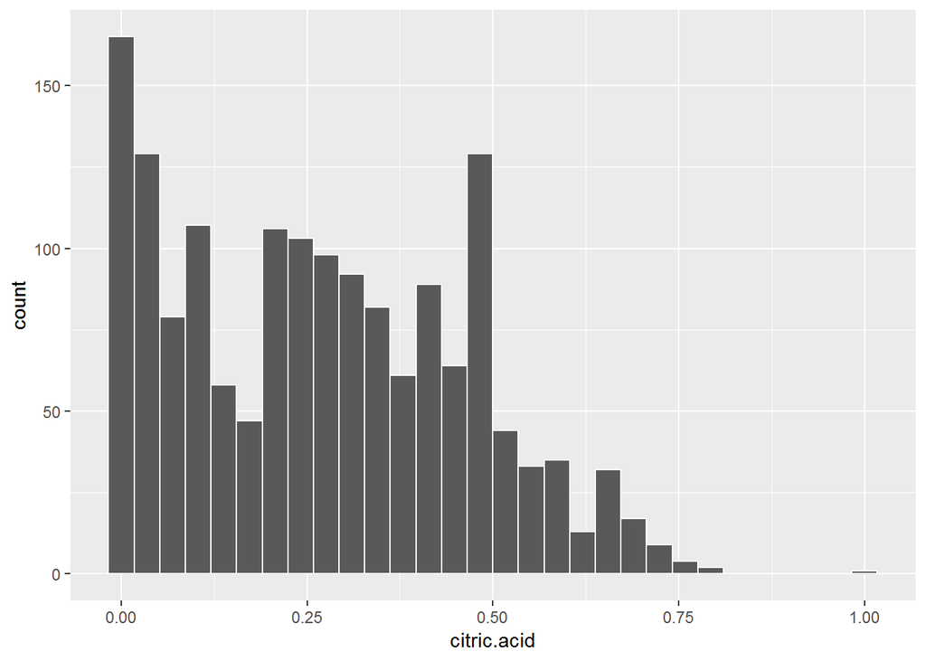

The distribution of Citric.acid is non-symmetric and Multimodal with more than one peak.

## Fixed Acidity

```
##    Min. 1st Qu.  Median    Mean 3rd Qu.    Max.
##    4.60    7.10    7.90    8.32    9.20   15.90
```

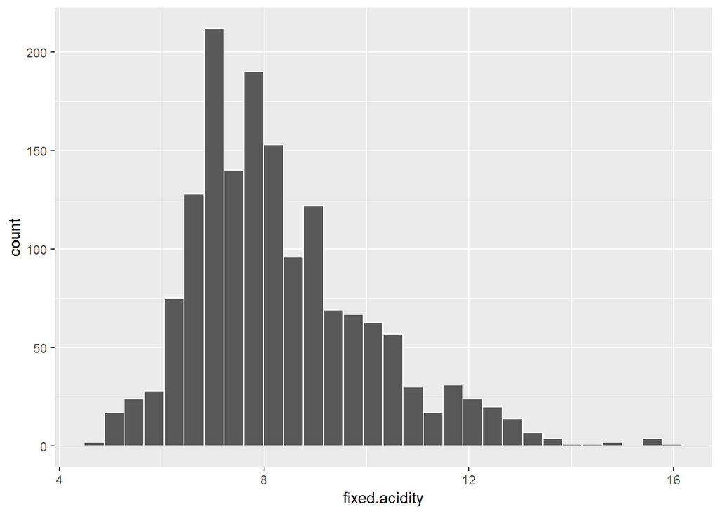

## Free sulfur dioxide

```
##    Min. 1st Qu.  Median    Mean 3rd Qu.    Max.
##    1.00    7.00   14.00   15.87   21.00   72.00
```

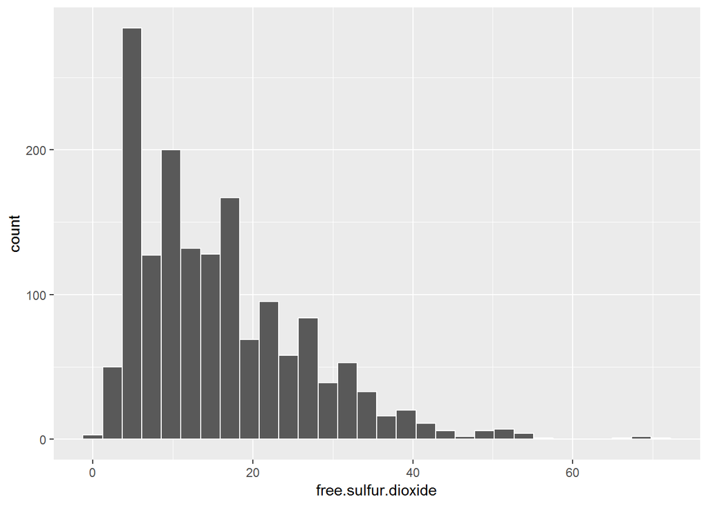

Free sulfur dioxide is right skewed and have a Median = 14 and Mean = 15.87

# Univariate Analysis

### What is the structure of your dataset?

The dataset has 12 variables and 1599 observations.

### What is/are the main feature(s) of interest in your dataset?

Quality

### What other features in the dataset do you think will help support your investigation into your feature(s) of interest?

The percentage of Alcohol and volatile acidity and The pH

### Did you create any new variables from existing variables in the dataset?

No

### Of the features you investigated, were there any unusual distributions? Did you perform any operations on the data to tidy, adjust, or change the form of the data? If so, why did you do this?

There were no unusual distributions, so i didn’t perform any operations on the data As this dataset is already tidy.

# Bivariate Plots Section

## Fixed Acidity And Quality

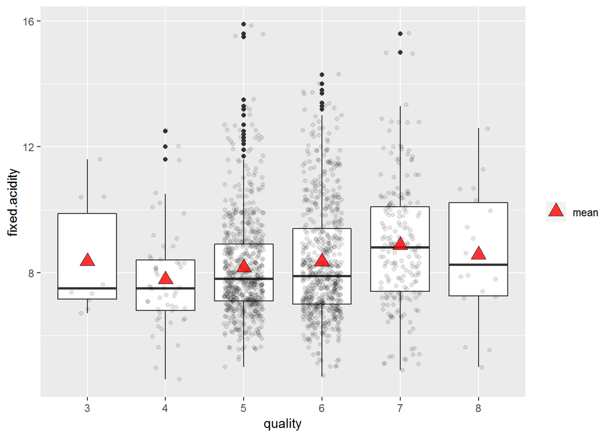

Quality rates 3 and 8 have low observations than the middle ones 5 and 6.

## volatile Acidity And Quality

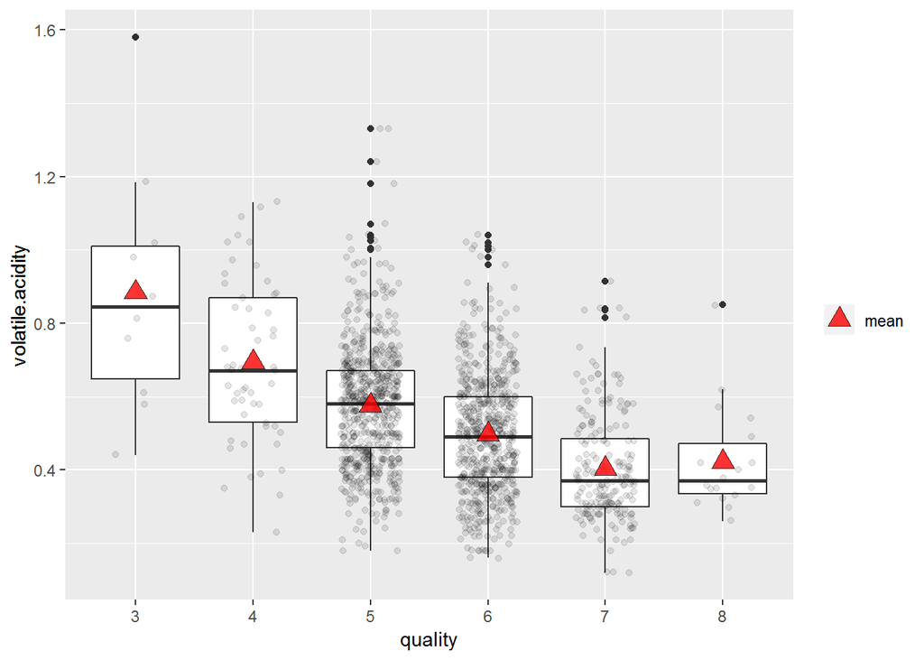

Quality rates 3 and 8 are extreme cases which have low observations than the middle ones 5 and 6.

But we can roughly conclude that lower volatile acidity ascocited with higher wine quality.

## pH And Quality

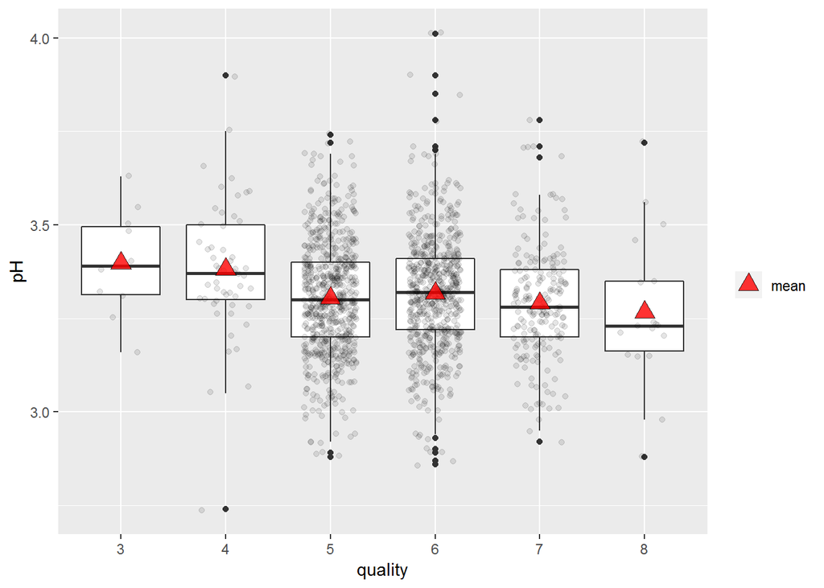

## Alcohol And Quality

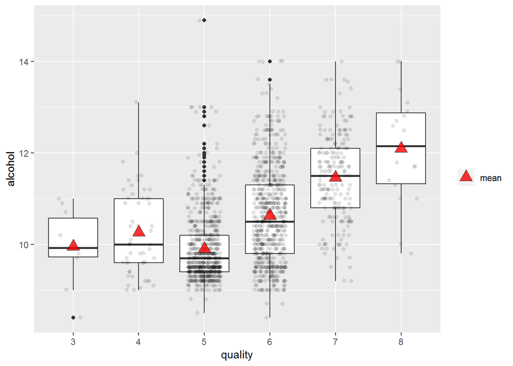

We can also conclude that higher the alcohol content ascocited with higher wine quality.

## Free sulfur dioxide And Quality

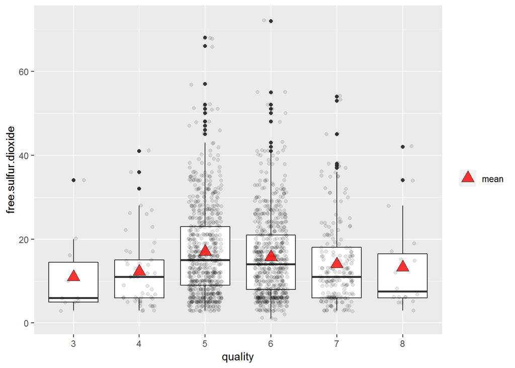

Quality rates 3 and 8 have low observations than the middle ones 5 and 6. The middle quality classes 5, 6 seem to have higher free sulfur dioxide than others.

## Citric acid And Quality

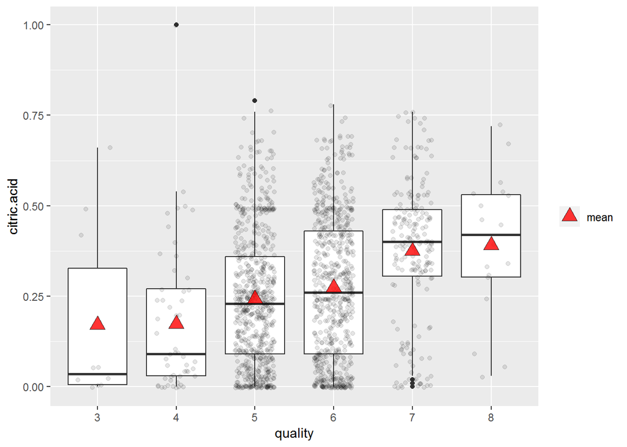

# Bivariate Analysis

Will Visualize the relationship between each pair of variables and find their correlations.

### Talk about some of the relationships you observed in this part of the investigation. How did the feature(s) of interest vary with other features in the dataset?

The wine quality is higher has stronger relationship with the volatile acidity and alcohol content. The correlation coefficients show the relationship with the variables.

```
##                             [,1]
## fixed.acidity         0.11408367
## volatile.acidity     -0.38064651
## citric.acid           0.21348091
## residual.sugar        0.03204817
## chlorides            -0.18992234
## free.sulfur.dioxide  -0.05690065
## total.sulfur.dioxide -0.19673508
## density              -0.17707407
## pH                   -0.04367193
## sulphates             0.37706020
## alcohol               0.47853169
```

### What was the strongest relationship you found?

The relationship between the quality and the alcohol content.

# Multivariate Plots Section

## Alcohol And Volatile acidity And quality

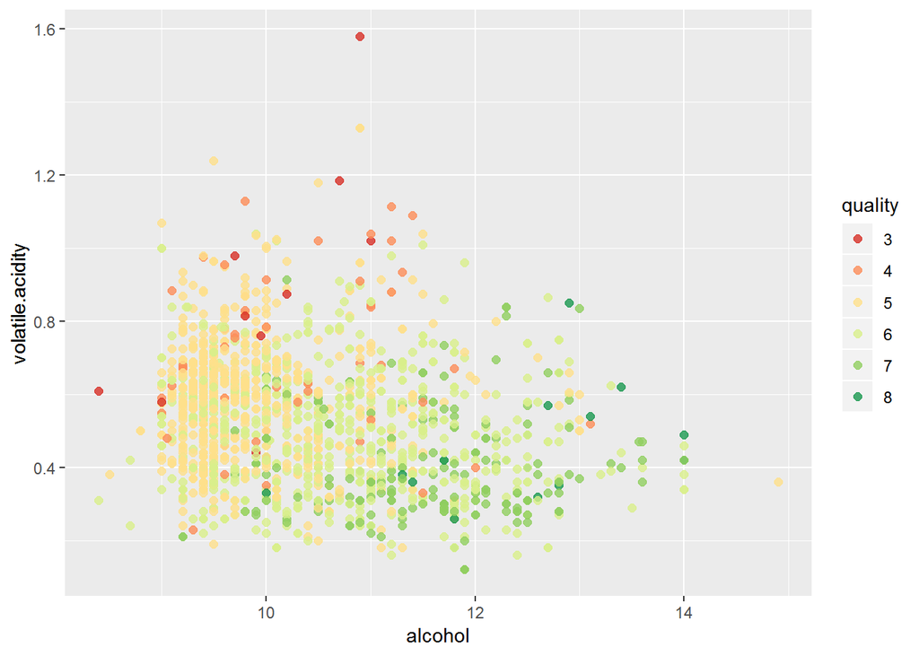

We can conclude that the lower quality wines associated with the lower alcohol and higher volatile acidity.

## Citric acid And Alcohol And Quality

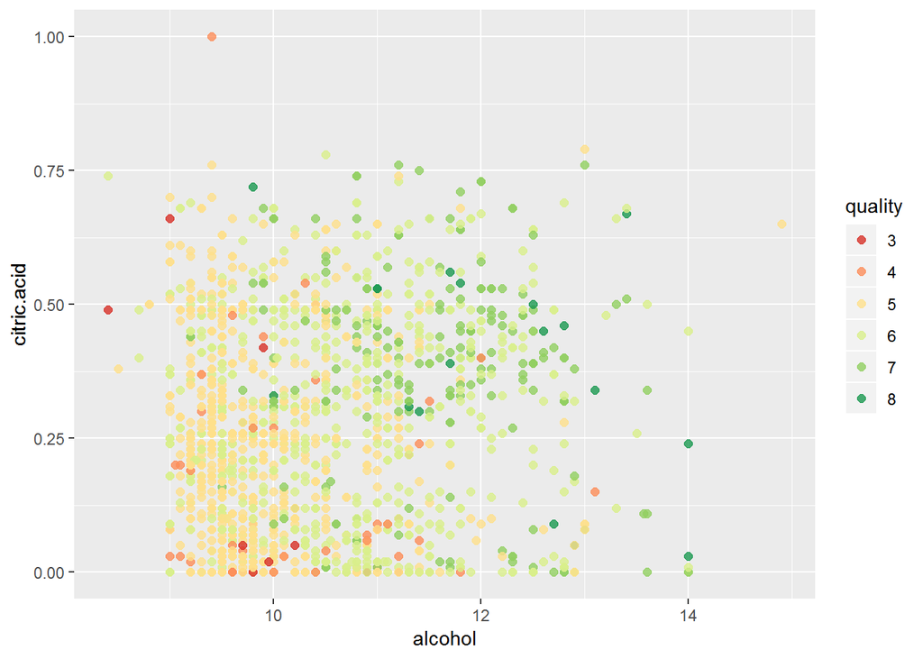

We can conclude that the higher quality wines associated with the higher citric acid and alcohol.

# Multivariate Analysis

### Talk about some of the relationships you observed in this part of the investigation. Were there features that strengthened each other in terms of looking at your feature(s) of interest?

The relationship between alcohol and volatile acidity and their relation with quality. Higher alcohol and lower acidity give in general better quality wines. Also the higher quality wines associated related to the higher citric acid and alcohol.

# Final Plots and Summary

### Plot One

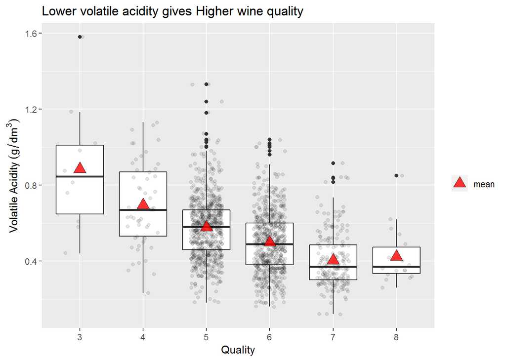

### Plot Two

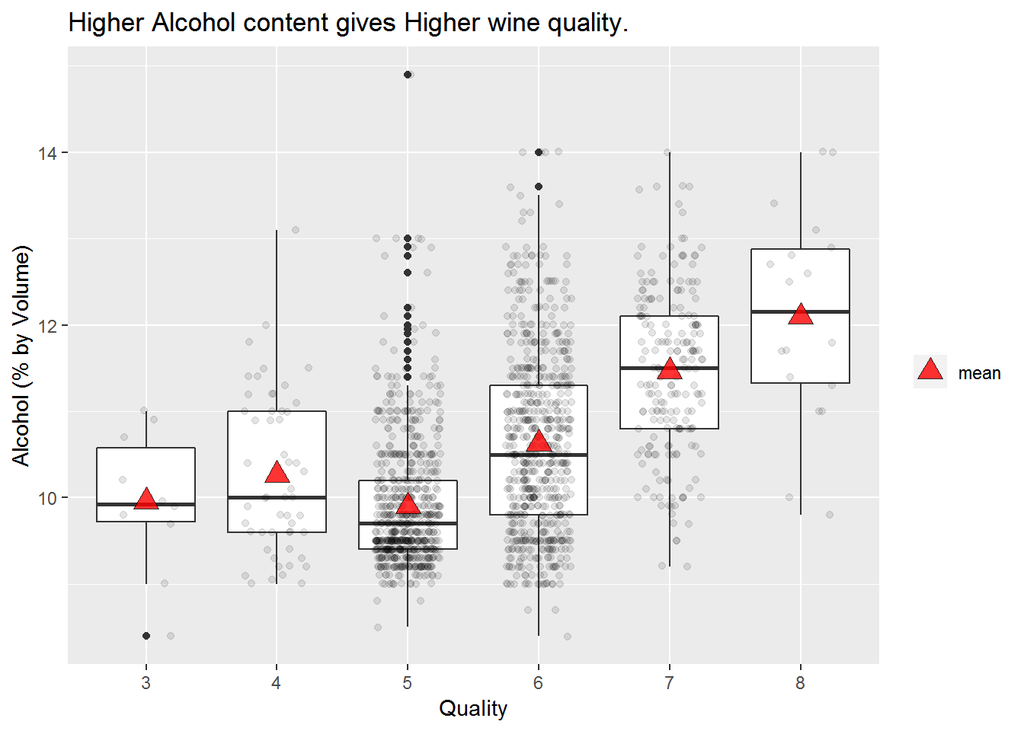

### Description Two

From the quality rating 5 to 8, There’s a big increase in the alcohol content. So we can conclude that Wines with higher alcohol content are rated highe quality.

### Plot Three

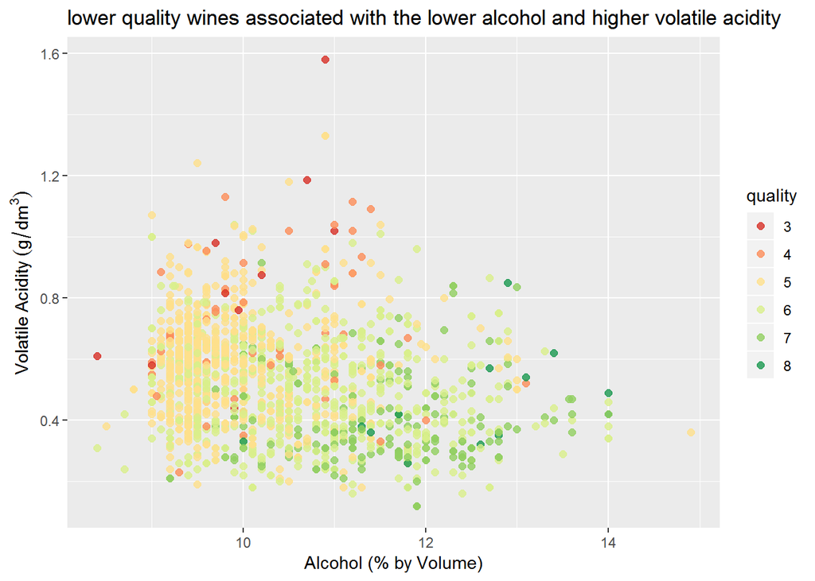

### Description Three

W e can conclude that Alcohol and volatile acidity had a big impact on the quality of the wines. On this plot we see the combined effect of this two variables on the quality. The wines with high volatile acidity and low alcohol have lower quality rating.And at low volatile acidity and high alcohol content we find the higher quality wines.

# Reflection

This is my first project in R so it’s a great challenge for me. And making visualization for more than two variables it became harder to grasp conclusions.

When working with such a dataset the first challenge is to choosw which variable to explore and find it’s relation with other variables but luckily, the dataset already hints at some variables of interest.it tells us that citric acid can add freshness to wines, while acetic acid can add an unpleasant vinegar taste. This shows how important it is to have specific domain knowledge while performing a data analysis.and When we do not have that domain knowledge, consulting with an expert in the field will be incredibly valuable to save time.

My Second challenge was making visualization for more than two variables as it became harder to grasp conclusions but it came up with good results thogh.

As Fusture work in this project, I could think of Use also the white wines dataset to see if we can come up with the same conclusions or it wil be different.

And further more As a next step I want to develop a machine learning model to predict red wine quality based on the data in this dataset.